# Data350 Final Modeling Project

brian avery

August 1, 2018

```r
library(car)
library(broom)
library(mosaic)
```

# Statistical Modeling Final Project

## Introduction

Start with a brief introduction that explains the data set you’ve chosen, giving some background information about the provenance and structure of the data. Do a little exploratory data analysis (graphs, charts, tables, etc.) to learn about the data.

This data set is a subset from a single site (Cleveland Clinic) of a multisite a cardiology study to develop a new probabilistic algorithm to diagnose coronary artery disease (Detrano et al., International Application of a New Probability Algorithm for the Diagnosis of Coronary Artery Disease, Am J Cardiol 1989;64:304-310.).  
The data was collected in the early 1980s and at the time there was little data and few models to predict the probability of coronary artery disease from diagnostic data.  
The authors collected data from 303 patients that had no previous history of major heart disease (heart attack, valve problems, etc.)

### codebook

info from - https://archive.ics.uci.edu/ml/machine-learning-databases/heart-disease/heart-disease.names The 14 variables below (included in the dataset used) are a subset of variables from the larger, complete dataset (the original variable numbers are shown at the end after #).  
1. age - age in years (#3)  
2. sex - sex (1 = male; 0 = female) (#4)  
3. cp - chest pain type - Value 1: typical angina, Value 2: atypical angina, Value 3: non-anginal pain, Value 4: asymptomatic (#9)  
4. trestbps - resting blood pressure (in mm Hg on admission to the hospital) (#10)  
5. chol - serum cholestoral in mg/dl (#12)  
6. fbs - fasting blood sugar > 120 mg/dl (1 = true; 0 = false) (#16)  
7. restecg - resting electrocardiographic results - Value 0: normal, Value 1: having ST-T wave abnormality (T wave inversions and/or ST elevation or depression of > 0.05 mV), Value 2: showing probable or definite left ventricular hypertrophy by Estes’ criteria (#19)  
8. thalach - maximum heart rate achieved (#32)  
9. exang - exercise induced angina (1 = yes; 0 = no) #38  
10. oldpeak - ST depression induced by exercise relative to rest (#40)  
11. slope - the slope of the peak exercise ST segment - Value 1: upsloping, Value 2: flat, Value 3: downsloping (#41)  
12. ca - number of major vessels (0-3) colored by flourosopy (#44)  
13. thal - 3 = normal; 6 = fixed defect; 7 = reversable defect (#51)  
14. num - diagnosis of heart disease (angiographic disease status) - Value 0: < 50% diameter narrowing, Value 1: > 50% diameter narrowing (in any major vessel: attributes 59 through 68 are vessels) - 0 is no disease, other values are disease (#58)

### Exploratory Data Analysis

#### get and prep data

my data source was this file converted to csv (in LibreOffice):  
https://archive.ics.uci.edu/ml/machine-learning-databases/heart-disease/processed.cleveland.data

First, we need to bring in the data:

```r
cleveland <- read.csv("processed.cleveland.csv")
str(cleveland)
```

```
## 'data.frame':    303 obs. of  14 variables:
##  $ age     : int  63 67 67 37 41 56 62 57 63 53 ...
##  $ sex     : int  1 1 1 1 0 1 0 0 1 1 ...
##  $ cp      : int  1 4 4 3 2 2 4 4 4 4 ...
##  $ trestbps: int  145 160 120 130 130 120 140 120 130 140 ...
##  $ chol    : int  233 286 229 250 204 236 268 354 254 203 ...
##  $ fbs     : int  1 0 0 0 0 0 0 0 0 1 ...
##  $ restecg : int  2 2 2 0 2 0 2 0 2 2 ...
##  $ thalach : int  150 108 129 187 172 178 160 163 147 155 ...
##  $ exang   : int  0 1 1 0 0 0 0 1 0 1 ...
##  $ oldpeak : num  2.3 1.5 2.6 3.5 1.4 0.8 3.6 0.6 1.4 3.1 ...
##  $ slope   : int  3 2 2 3 1 1 3 1 2 3 ...
##  $ ca      : Factor w/ 5 levels "?","0","1","2",..: 2 5 4 2 2 2 4 2 3 2 ...
##  $ thal    : Factor w/ 4 levels "?","3","6","7": 3 2 4 2 2 2 2 2 4 4 ...
##  $ num     : int  0 2 1 0 0 0 3 0 2 1 ...
```

I want to convert a few of the variables to factors in R based on the codebook descriptions.

```r
cleveland$sex <- factor(cleveland$sex, levels=c(1,0), labels=c('M', 'F'))
cleveland$cp <- factor(cleveland$cp, levels=c(1,2,3,4), labels=c('t_ang','a_ang', 'non-ang', 'asymp'))
cleveland$fbs <- factor(cleveland$fbs, levels=c(1,0), labels=c('high','low'))
cleveland$restecg <- factor(cleveland$restecg, levels=c(0,1,2), labels=c('normal', 'wave_abn','lv_hyp'))
cleveland$exang <- factor(cleveland$exang, levels=c(1,0), labels=c('Y', 'N'))
cleveland$slope <- factor(cleveland$slope, levels=c(1,2,3), labels=c('pos', 'flat', 'neg'))
cleveland$num <- factor(cleveland$num)
str(cleveland)
```

```
## 'data.frame':    303 obs. of  14 variables:
##  $ age     : int  63 67 67 37 41 56 62 57 63 53 ...
##  $ sex     : Factor w/ 2 levels "M","F": 1 1 1 1 2 1 2 2 1 1 ...
##  $ cp      : Factor w/ 4 levels "t_ang","a_ang",..: 1 4 4 3 2 2 4 4 4 4 ...
##  $ trestbps: int  145 160 120 130 130 120 140 120 130 140 ...
##  $ chol    : int  233 286 229 250 204 236 268 354 254 203 ...
##  $ fbs     : Factor w/ 2 levels "high","low": 1 2 2 2 2 2 2 2 2 1 ...
##  $ restecg : Factor w/ 3 levels "normal","wave_abn",..: 3 3 3 1 3 1 3 1 3 3 ...
##  $ thalach : int  150 108 129 187 172 178 160 163 147 155 ...
##  $ exang   : Factor w/ 2 levels "Y","N": 2 1 1 2 2 2 2 1 2 1 ...
##  $ oldpeak : num  2.3 1.5 2.6 3.5 1.4 0.8 3.6 0.6 1.4 3.1 ...
##  $ slope   : Factor w/ 3 levels "pos","flat","neg": 3 2 2 3 1 1 3 1 2 3 ...
##  $ ca      : Factor w/ 5 levels "?","0","1","2",..: 2 5 4 2 2 2 4 2 3 2 ...
##  $ thal    : Factor w/ 4 levels "?","3","6","7": 3 2 4 2 2 2 2 2 4 4 ...
##  $ num     : Factor w/ 5 levels "0","1","2","3",..: 1 3 2 1 1 1 4 1 3 2 ...
```

Now I want a categorical variable that tells us whether the patient was diagnosed with a disease or not, I’m going to make a categorical variable here that does that. I’m basing my decision on the description of the `num` variable, which says “0 is no disease, other values are disease”.

```r
cleveland <- mutate(cleveland, disease=num!=0)
str(cleveland)
```

```
## 'data.frame':    303 obs. of  15 variables:
##  $ age     : int  63 67 67 37 41 56 62 57 63 53 ...
##  $ sex     : Factor w/ 2 levels "M","F": 1 1 1 1 2 1 2 2 1 1 ...
##  $ cp      : Factor w/ 4 levels "t_ang","a_ang",..: 1 4 4 3 2 2 4 4 4 4 ...
##  $ trestbps: int  145 160 120 130 130 120 140 120 130 140 ...
##  $ chol    : int  233 286 229 250 204 236 268 354 254 203 ...
##  $ fbs     : Factor w/ 2 levels "high","low": 1 2 2 2 2 2 2 2 2 1 ...
##  $ restecg : Factor w/ 3 levels "normal","wave_abn",..: 3 3 3 1 3 1 3 1 3 3 ...
##  $ thalach : int  150 108 129 187 172 178 160 163 147 155 ...
##  $ exang   : Factor w/ 2 levels "Y","N": 2 1 1 2 2 2 2 1 2 1 ...
##  $ oldpeak : num  2.3 1.5 2.6 3.5 1.4 0.8 3.6 0.6 1.4 3.1 ...
##  $ slope   : Factor w/ 3 levels "pos","flat","neg": 3 2 2 3 1 1 3 1 2 3 ...
##  $ ca      : Factor w/ 5 levels "?","0","1","2",..: 2 5 4 2 2 2 4 2 3 2 ...
##  $ thal    : Factor w/ 4 levels "?","3","6","7": 3 2 4 2 2 2 2 2 4 4 ...
##  $ num     : Factor w/ 5 levels "0","1","2","3",..: 1 3 2 1 1 1 4 1 3 2 ...
##  $ disease : logi  FALSE TRUE TRUE FALSE FALSE FALSE ...
```

Just to be sure I did that right, I want to compare the number of zeros in the `num` variable with the number of `FALSE` values in the `disease` variable.

```r
tally(cleveland$disease)
```

```
## X
##  TRUE FALSE
##   139   164
```

```r
tally(cleveland$num)
```

```
## X
##   0   1   2   3   4
## 164  55  36  35  13
```

They are the same, and 55+36+35+13 = 139 which is the same as the `TRUE` values, so seems OK.

Here is a summary of the data by variable:

```r
summary(cleveland)
```

```
##       age       sex           cp         trestbps        chol       fbs          restecg
##  Min.   :29.0   M:206   t_ang  : 23   Min.   : 94   Min.   :126   high: 45   normal  :151
##  1st Qu.:48.0   F: 97   a_ang  : 50   1st Qu.:120   1st Qu.:211   low :258   wave_abn:  4
##  Median :56.0           non-ang: 86   Median :130   Median :241              lv_hyp  :148
##  Mean   :54.4           asymp  :144   Mean   :132   Mean   :247
##  3rd Qu.:61.0                         3rd Qu.:140   3rd Qu.:275
##  Max.   :77.0                         Max.   :200   Max.   :564
##     thalach    exang      oldpeak      slope     ca      thal    num      disease
##  Min.   : 71   Y: 99   Min.   :0.00   pos :142   ?:  4   ?:  2   0:164   Mode :logical
##  1st Qu.:134   N:204   1st Qu.:0.00   flat:140   0:176   3:166   1: 55   FALSE:164
##  Median :153           Median :0.80   neg : 21   1: 65   6: 18   2: 36   TRUE :139
##  Mean   :150           Mean   :1.04              2: 38   7:117   3: 35
##  3rd Qu.:166           3rd Qu.:1.60              3: 20           4: 13
##  Max.   :202           Max.   :6.20
```

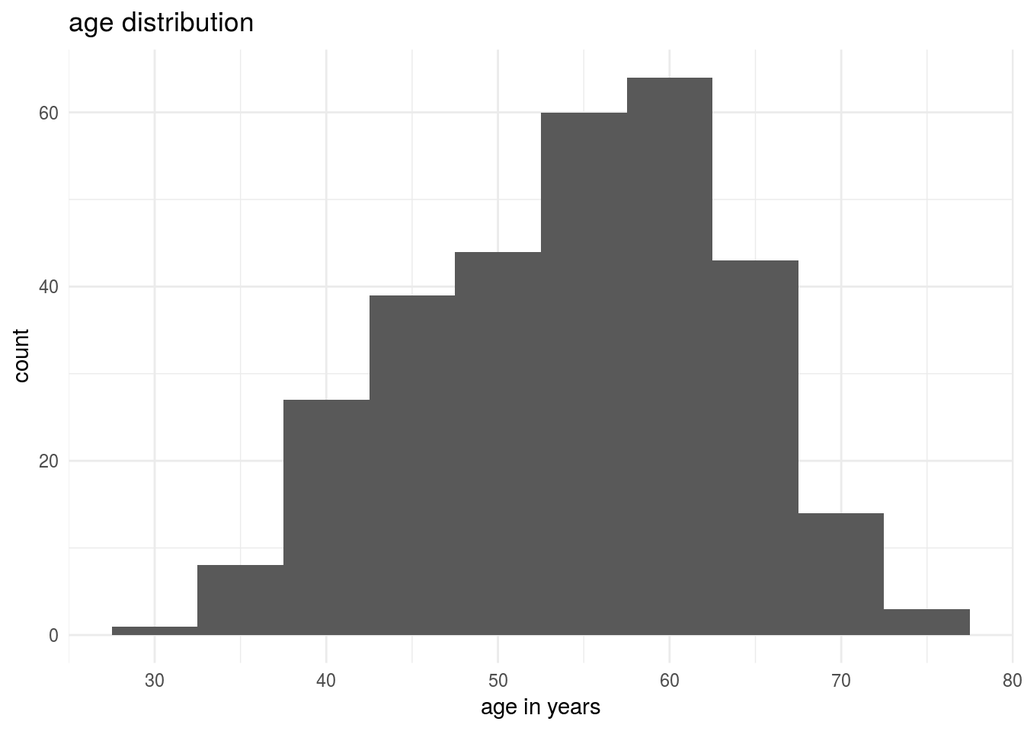

```r
ggplot(cleveland, aes(x = age)) +
  geom_histogram(binwidth=5) + theme_minimal() +
  labs(title="age distribution", x="age in years", y="count")
```

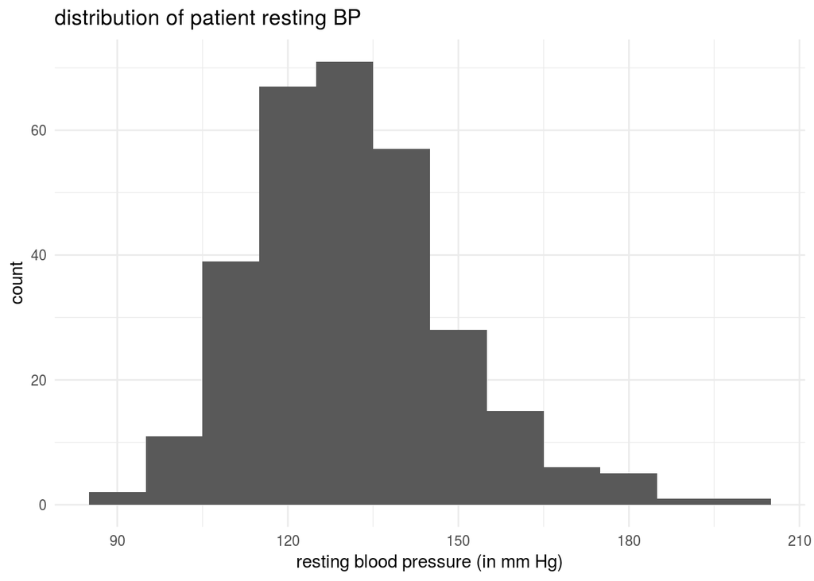

```r
ggplot(cleveland, aes(x = trestbps)) +
  geom_histogram(binwidth=10) + theme_minimal() +
  labs(title="distribution of patient resting BP", x="resting blood pressure (in mm Hg)", y="count")
```

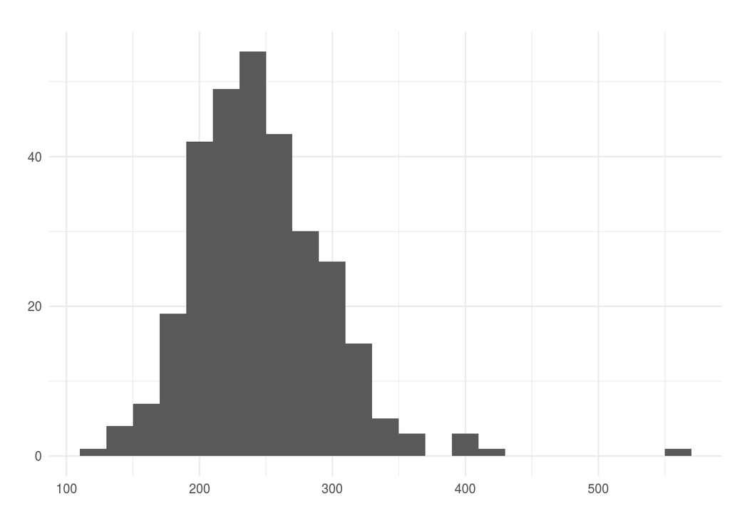

```r
ggplot(cleveland, aes(x = chol)) +
  geom_histogram(binwidth=20) + theme_minimal() +
  labs(title="", x="", y="")
```

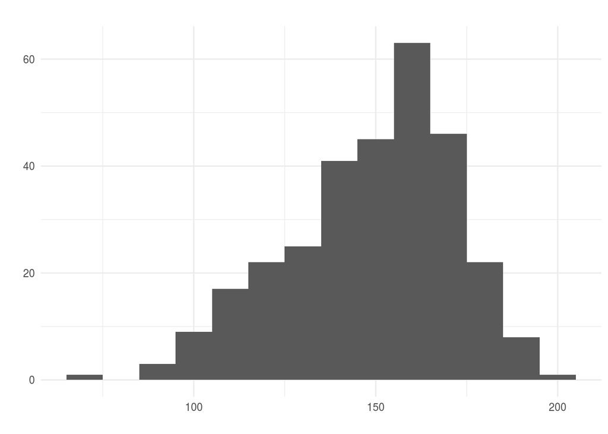

```r
ggplot(cleveland, aes(x = thalach)) +
  geom_histogram(binwidth=10) + theme_minimal() +
  labs(title="", x="", y="")
```

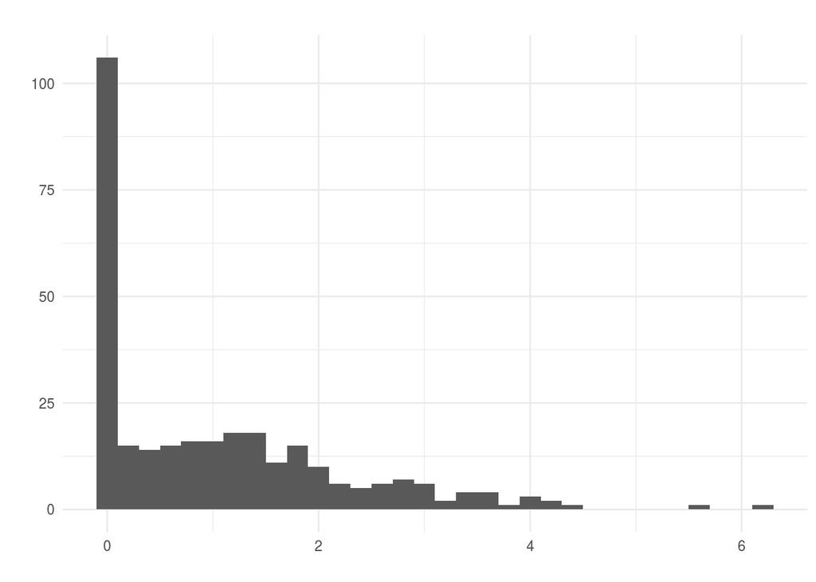

```r
ggplot(cleveland, aes(x = oldpeak))+
  geom_histogram(binwidth=.20) + theme_minimal() +
  labs(title="", x="", y="")
```

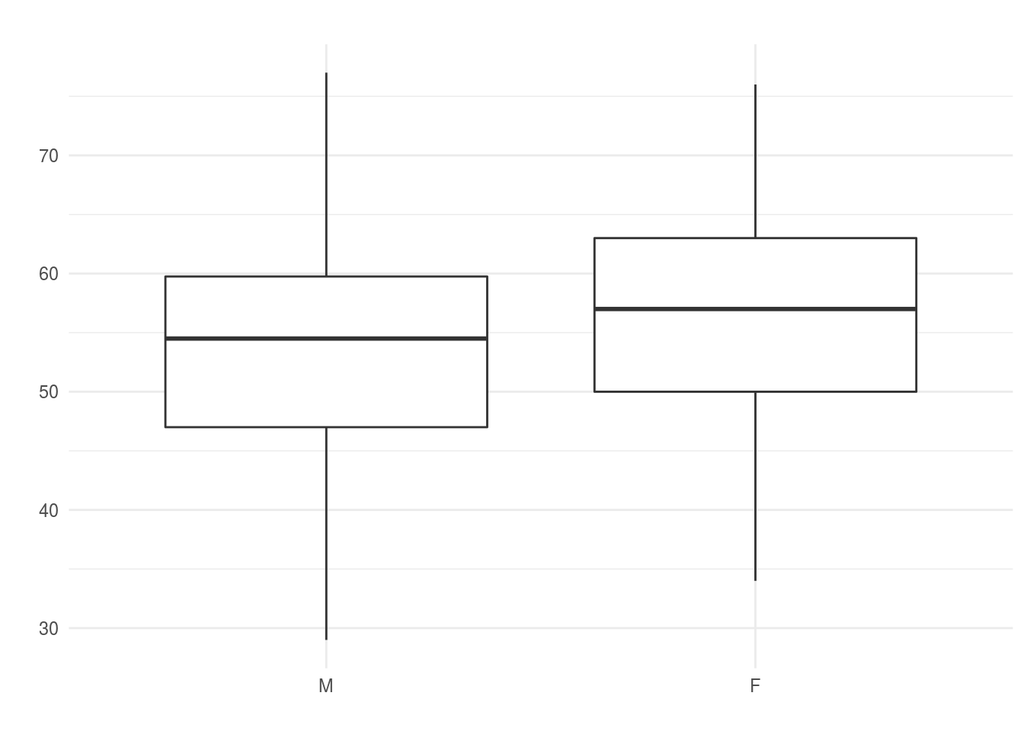

```r
ggplot(cleveland, aes(x=sex, y=age))+ geom_boxplot() + theme_minimal() +
  labs(title="", x="", y="")
```

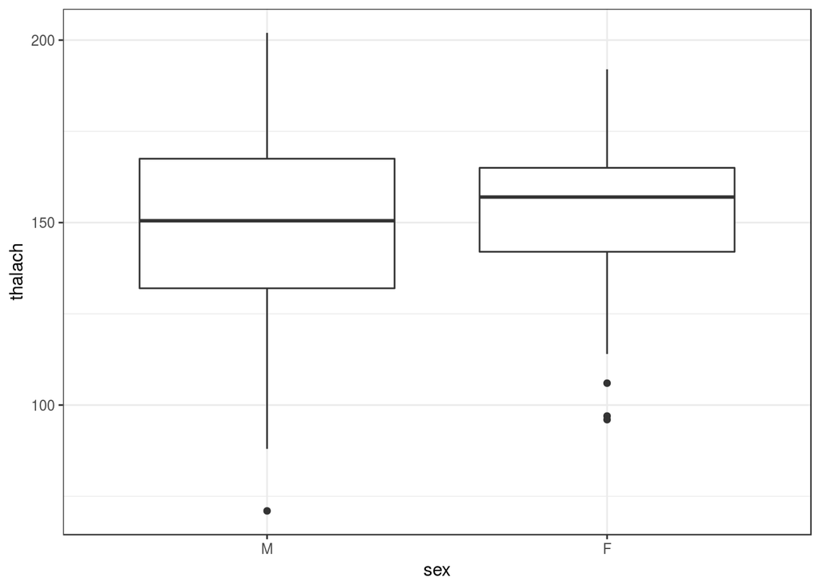

```r
ggplot(cleveland, aes(x=sex, y=thalach)) + geom_boxplot() + theme_bw()
```

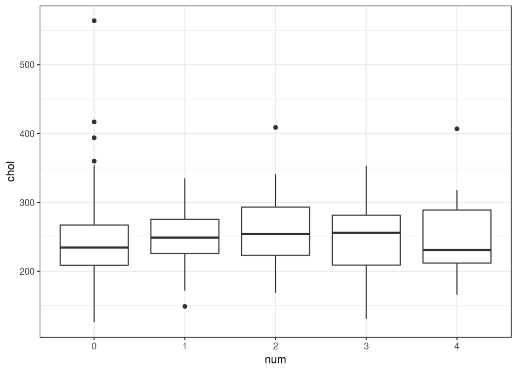

```r
ggplot(cleveland, aes(x=num, y=chol)) + geom_boxplot() + theme_bw()
```

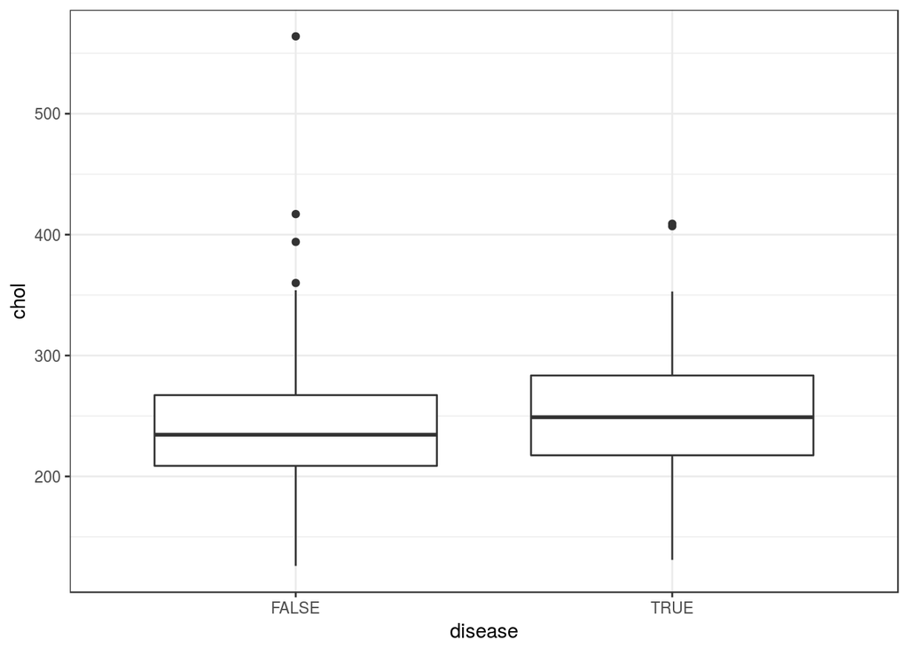

```r
ggplot(cleveland, aes(x=disease, y=chol)) + geom_boxplot() + theme_bw()
```

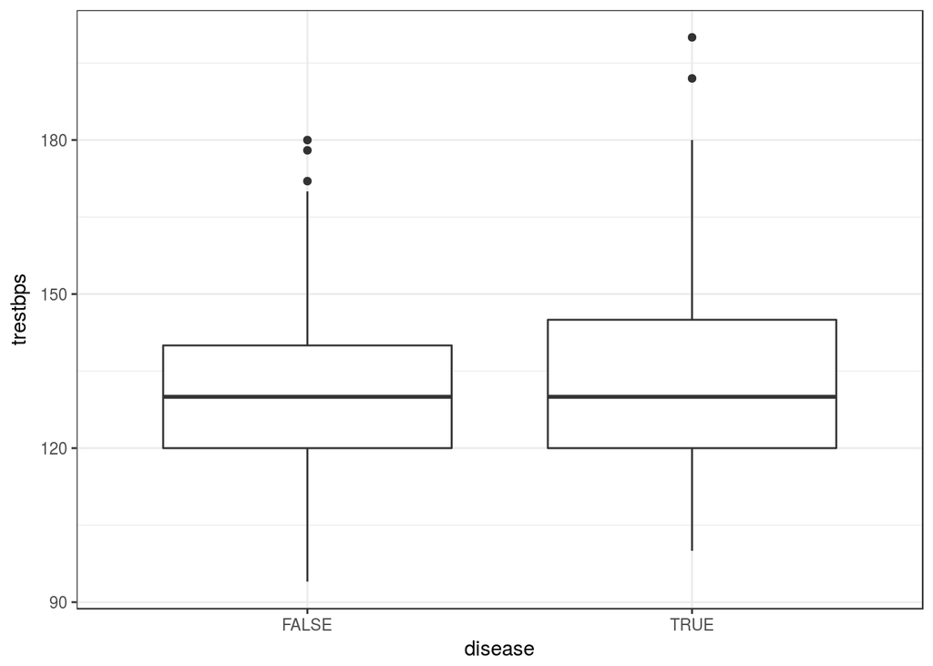

```r
ggplot(cleveland, aes(x=disease, y=trestbps)) + geom_boxplot() + theme_bw()
```

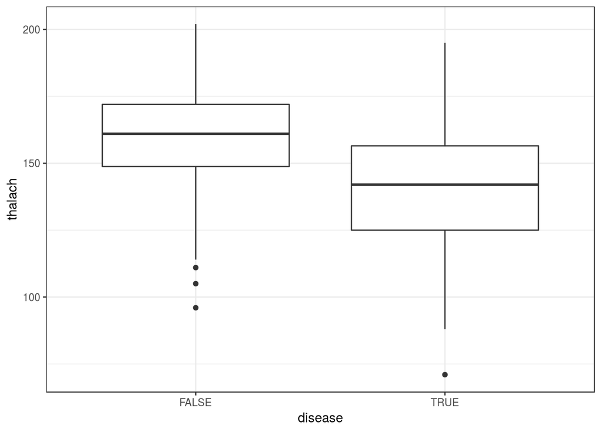

```r
ggplot(cleveland, aes(x=disease, y=thalach)) + geom_boxplot() + theme_bw()
```

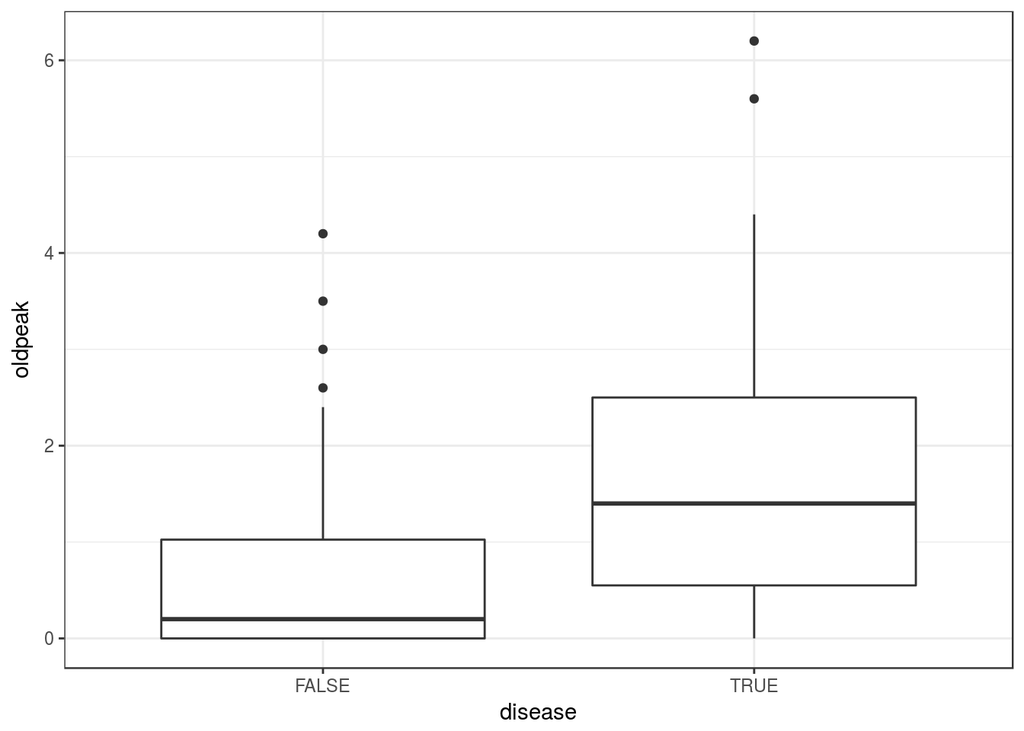

```r
ggplot(cleveland, aes(x=disease, y=oldpeak)) + geom_boxplot() + theme_bw()
```

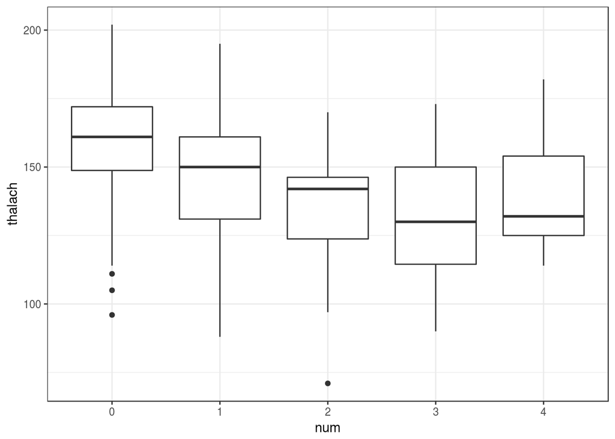

```r
ggplot(cleveland, aes(x=num, y=thalach)) + geom_boxplot() + theme_bw()
```

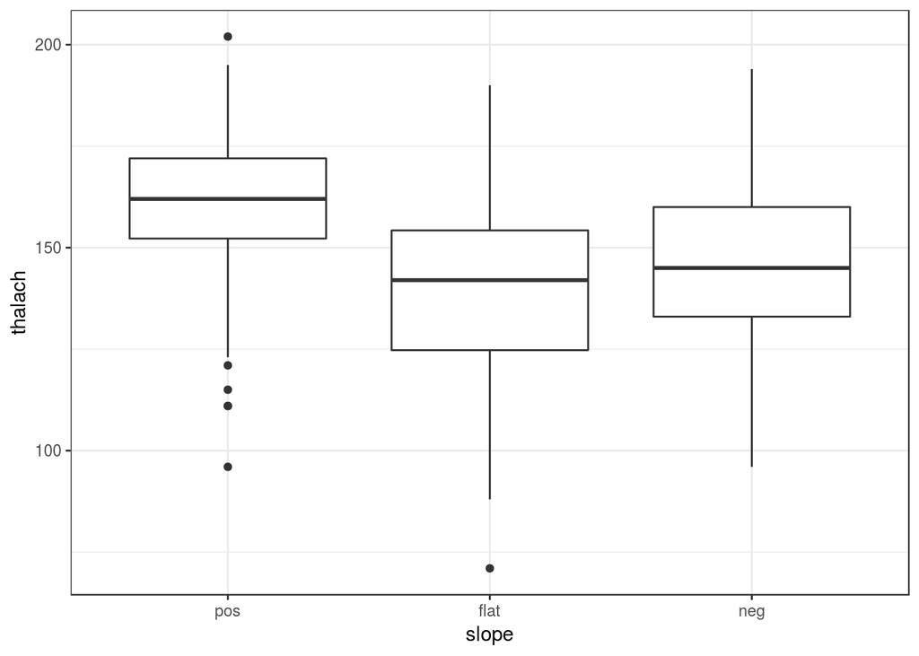

```r
ggplot(cleveland, aes(x=slope, y=thalach, group=slope)) + geom_boxplot() + theme_bw()
```

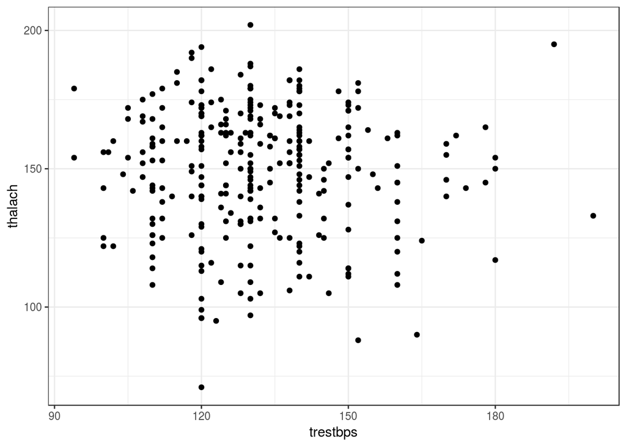

```r
ggplot(cleveland, aes(x=trestbps, y=thalach)) + geom_point() + theme_bw()
```

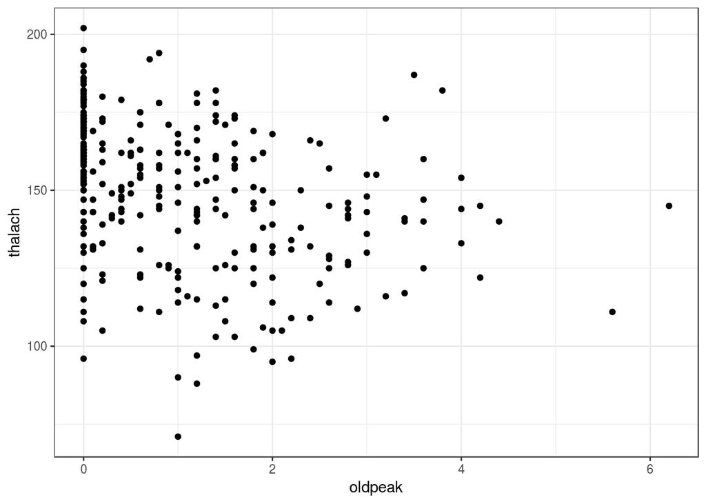

```r
ggplot(cleveland, aes(x=oldpeak, y=thalach)) + geom_point() + theme_bw()
```

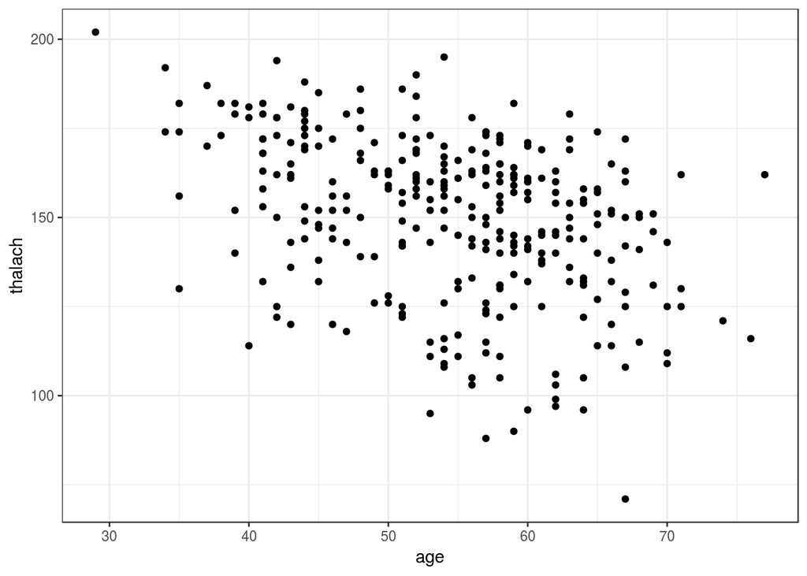

```r
ggplot(cleveland, aes(x=age, y=thalach)) + geom_point() + theme_bw()
```

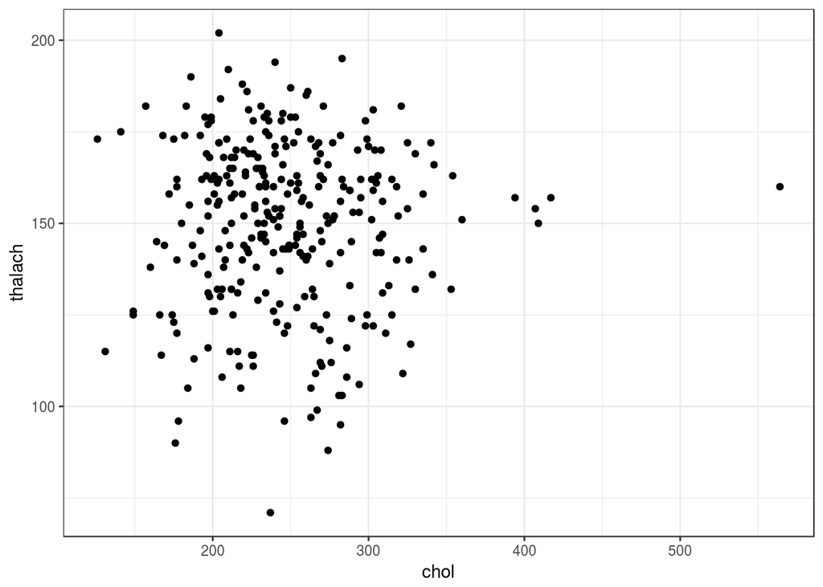

```r
ggplot(cleveland, aes(x=chol, y=thalach)) + geom_point() + theme_bw()
```

## Mechanics

In the next part of your project, you will go through some “mechanical” tasks that demonstrate your ability to run basic types of analysis in R. These tasks will not necessarily be “good” models and you don’t need to worry about the conclusions expressing anything meaningful. Here are the tasks you need to complete:

### Multiple regression, part 1

Use a numerical response variable and at least two numerical explanatory variables.  
Check scatterplots and residual plots. But even if the scatterplots and residual plots show that a multiple regression analysis is inappropriate, go ahead and run the analysis anyway.  
Interpret the coefficients of the model, including the intercept (even when such coefficients might not make any sense for a variety of reasons).

```r
HR_model <- lm(thalach ~ age + oldpeak + chol, data=cleveland)
HR_model_tidy <- tidy(HR_model)
HR_model_tidy
```

| term | estimate | std.error | statistic | p.value |
| --- | --- | --- | --- | --- |
| (Intercept) | 195.072977 | 8.208400 | 23.7650 | 7.5167e-71 |
| age | -0.899232 | 0.133666 | -6.7275 | 8.7865e-11 |
| oldpeak | -5.409316 | 1.018690 | -5.3101 | 2.1418e-07 |
| chol | 0.036933 | 0.022869 | 1.6150 | 1.0737e-01 |

### Multiple regression, part 2

Use a numerical response variable, one numerical explanatory variable, and one categorical explanatory variable. (Allow R to use the default dummy coding with the categorical variable.)  
Check scatterplots and residual plots. But even if the scatterplots and residual plots show that a multiple regression analysis is inappropriate, go ahead and run the analysis anyway.  
Interpret the coefficients of the model, including the intercept (even when such coefficients might not make any sense for a variety of reasons).

```r
HR_model2 <- lm(thalach ~ age + as.factor(slope), data=cleveland)
HR_model2_tidy <- tidy(HR_model2)
HR_model2_tidy
```

| term | estimate | std.error | statistic | p.value |
| --- | --- | --- | --- | --- |
| (Intercept) | 203.26739 | 6.74517 | 30.1353 | 1.3045e-92 |
| age | -0.81265 | 0.12438 | -6.5337 | 2.7594e-10 |
| as.factor(slope)flat | -18.38507 | 2.32590 | -7.9045 | 5.2156e-14 |
| as.factor(slope)neg | -13.35750 | 4.50067 | -2.9679 | 3.2409e-03 |

### ANOVA

Use a numerical response variable, and two categorical explanatory variables.  
Create an interaction plot.  
Use deviance coding (with “contr.sum” in R) and run the model including an interaction term.  
Test for the presence of interaction between the two explanatory variables.  
Interpret the coefficients of the model, including the intercept (even when such coefficients might not make any sense for a variety of reasons).

Variables: slope, sex

```r
# group means
gr_means <- cleveland %>%
    group_by(as.factor(slope), as.factor(sex)) %>%
    summarize(mean_thalach = mean(thalach))
gr_means
```

| as.factor(slope) | as.factor(sex) | mean_thalach |
| --- | --- | --- |
| pos | M | 161.54 |
| pos | F | 158.32 |
| flat | M | 136.68 |
| flat | F | 144.80 |
| neg | M | 145.69 |
| neg | F | 142.40 |

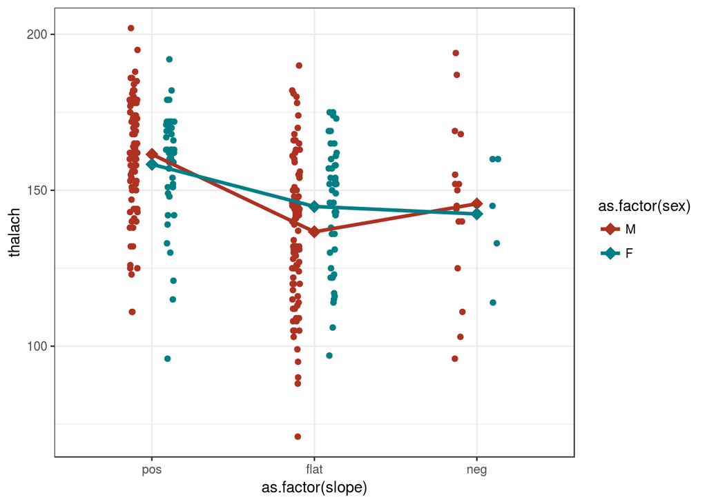

```r
# interaction plot
ggplot() +
  geom_point(data = cleveland, aes(as.factor(slope), thalach, color = as.factor(sex)),
             position=position_jitterdodge(jitter.width=0.1, dodge.width=0.45)) +
  geom_point(data = gr_means, aes(`as.factor(slope)`, mean_thalach, color = `as.factor(sex)`),
             shape=18, size=4) +
  geom_line(data = gr_means, aes(`as.factor(slope)`, mean_thalach, group=`as.factor(sex)`, color=`as.factor(sex)`),
            size=1.2) + scale_colour_hue(l=40) + theme_bw()
```

```r
HR_model3 <- lm(thalach ~ as.factor(slope) + as.factor(sex) + as.factor(slope):as.factor(sex),
                data=cleveland)
HR_model3_tidy <- tidy(HR_model3)
HR_model3_tidy
```

| term | estimate | std.error | statistic | p.value |
| --- | --- | --- | --- | --- |
| (Intercept) | 161.536842 | 2.0924 | 77.2020022 | 1.3125e-198 |
| as.factor(slope)flat | -24.852632 | 2.9591 | -8.3987443 | 1.8815e-15 |
| as.factor(slope)neg | -15.849342 | 5.5112 | -2.8758532 | 4.3209e-03 |
| as.factor(sex)F | -3.217693 | 3.6370 | -0.8847210 | 3.7702e-01 |
| as.factor(slope)flat:as.factor(sex)F | 11.333483 | 5.1815 | 2.1872859 | 2.9501e-02 |
| as.factor(slope)neg:as.factor(sex)F | -0.069807 | 11.0637 | -0.0063095 | 9.9497e-01 |

```r
HR_model3_Aov <- Anova(HR_model3)
HR_model3_Aov
```

|  | Sum Sq | Df | F value | Pr(>F) |
| --- | --- | --- | --- | --- |
| as.factor(slope) | 32019.28 | 2 | 38.49213 | 1.3665e-15 |
| as.factor(sex) | 273.43 | 1 | 0.65741 | 4.1813e-01 |
| as.factor(slope):as.factor(sex) | 2104.56 | 2 | 2.53001 | 8.1374e-02 |
| Residuals | 123528.20 | 297 | NA | NA |

## Model and Hypothesis

For the final part of the project, go through the process of specifying a contextually meaningful model that tests a reasonable hypothesis. In addition to the steps you have done above, be sure to transform any variables that need transforming, do a thorough search for outliers and test them for influence, and run any other model diagnostics that are appropriate for your specific data. Use your model to come to a meaningful conclusion and learn something from your analysis.